Skip to content

# Timing-associated geneset analysis with cellfategenie

In our single-cell analysis, we analyse the underlying temporal state in the cell, which we call pseudotime. and identifying the genes associated with pseudotime becomes the key to unravelling models of gene dynamic regulation. In traditional analysis, we would use correlation coefficients, or gene dynamics model fitting. The correlation coefficient approach will have a preference for genes at the beginning and end of the time series, and the gene dynamics model requires RNA velocity information. Unbiased identification of chronosequence-related genes, as well as the need for no additional dependency information, has become a challenge in current chronosequence analyses.

Here, we developed CellFateGenie, which first removes potential noise from the data through metacells, and then constructs an adaptive ridge regression model to find the minimum set of genes needed to satisfy the timing fit.CellFateGenie has similar accuracy to gene dynamics models while eliminating preferences for the start and end of the time series.

We provided the AUCell to evaluate the geneset of adata

Colab_Reproducibility：https://colab.research.google.com/drive/1upcKKZHsZMS78eOliwRAddbaZ9ICXSrc?usp=sharing

```python
import omicverse as ov
import scvelo as scv
import matplotlib.pyplot as plt
ov.ov_plot_set()
```

import omicverse as ov import scvelo as scv import matplotlib.pyplot as plt ov.ov_plot_set()

## Data preprocessed

We using dataset of dentategyrus in scvelo to demonstrate the timing-associated genes analysis. Firstly, We use `ov.pp.qc` and `ov.pp.preprocess` to preprocess the dataset.

Then we use `ov.pp.scale` and `ov.pp.pca` to analysis the principal component of the data

```python
adata=ov.read('data/tutorial_meta_den.h5ad')
adata=adata.raw.to_adata()
adata
```

adata=ov.read('data/tutorial_meta_den.h5ad') adata=adata.raw.to_adata() adata

```
AnnData object with n_obs × n_vars = 200 × 13118
    obs: 'Pseudo-sizes', 'celltype', 'celltype_purity', 'pt_via'
    uns: 'celltype_colors', 'hvg', 'neighbors', 'scaled|original|cum_sum_eigenvalues', 'scaled|original|pca_var_ratios', 'umap'
    obsm: 'X_umap', 'scaled|original|X_pca'
    obsp: 'connectivities', 'distances'
```

## Genesets evaluata

```python
import omicverse as ov
pathway_dict=ov.utils.geneset_prepare('../placenta/genesets/GO_Biological_Process_2021.txt',organism='Mouse')
len(pathway_dict.keys())
```

import omicverse as ov pathway_dict=ov.utils.geneset_prepare('../placenta/genesets/GO_Biological_Process_2021.txt',organism='Mouse') len(pathway_dict.keys())

```
6036
```

```python
##Assest all pathways
adata_aucs=ov.single.pathway_aucell_enrichment(adata,
                                                pathways_dict=pathway_dict,
                                                num_workers=8)
```

##Assest all pathways adata_aucs=ov.single.pathway_aucell_enrichment(adata, pathways_dict=pathway_dict, num_workers=8)

```python
adata_aucs.obs=adata[adata_aucs.obs.index].obs
adata_aucs.obsm=adata[adata_aucs.obs.index].obsm
adata_aucs.obsp=adata[adata_aucs.obs.index].obsp
adata_aucs.uns=adata[adata_aucs.obs.index].uns

adata_aucs
```

adata_aucs.obs=adata[adata_aucs.obs.index].obs adata_aucs.obsm=adata[adata_aucs.obs.index].obsm adata_aucs.obsp=adata[adata_aucs.obs.index].obsp adata_aucs.uns=adata[adata_aucs.obs.index].uns adata_aucs

```
AnnData object with n_obs × n_vars = 200 × 6036
    obs: 'Pseudo-sizes', 'celltype', 'celltype_purity', 'pt_via'
    uns: 'celltype_colors', 'hvg', 'neighbors', 'scaled|original|cum_sum_eigenvalues', 'scaled|original|pca_var_ratios', 'umap'
    obsm: 'X_umap', 'scaled|original|X_pca'
    obsp: 'connectivities', 'distances'
```

## Timing-associated genes analysis

We have encapsulated the cellfategenie algorithm into omicverse, and we can simply use omicverse to analysis.

```python
cfg_obj=ov.single.cellfategenie(adata_aucs,pseudotime='pt_via')
cfg_obj.model_init()
```

cfg_obj=ov.single.cellfategenie(adata_aucs,pseudotime='pt_via') cfg_obj.model_init()

```
$MSE|RMSE|MAE|R^2$:0.0057|0.075|0.058|0.94
```

| Regulon | coef | abs(coef) | values |
| --- | --- | --- | --- |
| kidney morphogenesis (GO:0060993) | -0.073373 | 0.073373 | 0.131669 |
| protein de-ADP-ribosylation (GO:0051725) | 0.060204 | 0.060204 | 0.182627 |
| coronary artery morphogenesis (GO:0060982) | -0.055837 | 0.055837 | 0.073891 |
| isoleucine metabolic process (GO:0006549) | -0.055651 | 0.055651 | 0.269442 |
| fatty acid derivative catabolic process (GO:1901569) | -0.052161 | 0.052161 | 0.423015 |
| ... | ... | ... | ... |
| negative regulation of peptidase activity (GO:0010466) | 0.000000 | 0.000000 | 0.000000 |
| negative regulation of pathway-restricted SMAD protein phosphorylation (GO:0060394) | 0.000000 | 0.000000 | 0.000000 |
| negative regulation of oxidoreductase activity (GO:0051354) | 0.000000 | 0.000000 | 0.000000 |
| negative regulation of oxidative stress-induced neuron death (GO:1903204) | 0.000000 | 0.000000 | 0.000000 |
| zymogen inhibition (GO:0097341) | 0.000000 | 0.000000 | 0.000000 |

6036 rows × 3 columns

We used Adaptive Threshold Regression to calculate the minimum number of gene sets that would have the same accuracy as the regression model constructed for all genes.

```python
cfg_obj.ATR(stop=500)
```

cfg_obj.ATR(stop=500)

```
coef_threshold:0.01839457079768181, r2:0.939279664515779
```

|  | coef_threshold | r2 |
| --- | --- | --- |
| 0 | 0.060204 | 0.455190 |
| 1 | 0.055837 | 0.467974 |
| 2 | 0.055651 | 0.613062 |
| 3 | 0.052161 | 0.689825 |
| 4 | 0.050659 | 0.709170 |
| ... | ... | ... |
| 995 | 0.008238 | 0.942300 |
| 996 | 0.008232 | 0.942246 |
| 997 | 0.008226 | 0.942244 |
| 998 | 0.008220 | 0.942232 |
| 999 | 0.008216 | 0.942131 |

1000 rows × 2 columns

```python
fig,ax=cfg_obj.plot_filtering(color='#5ca8dc')
ax.set_title('Dentategyrus Metacells\nCellFateGenie')
```

fig,ax=cfg_obj.plot_filtering(color='#5ca8dc') ax.set_title('Dentategyrus Metacells\nCellFateGenie')

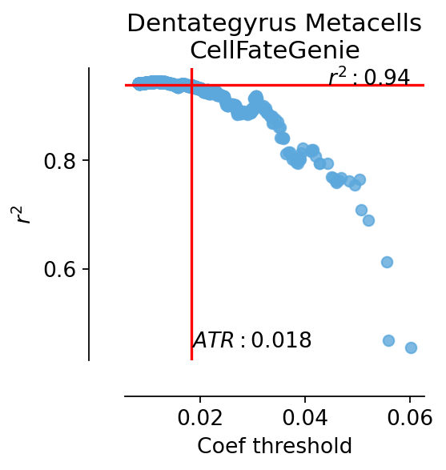

```python
res=cfg_obj.model_fit()
```

res=cfg_obj.model_fit()

```
$MSE|RMSE|MAE|R^2$:0.0068|0.083|0.061|0.93
```

## Visualization

We prepared a series of function to visualize the result. we can use `plot_color_fitting` to observe the different cells how to transit with the pseudotime.

```python
cfg_obj.plot_color_fitting(type='raw',cluster_key='celltype')
```

cfg_obj.plot_color_fitting(type='raw',cluster_key='celltype')

```
(<Figure size 240x240 with 1 Axes>,
 <AxesSubplot: title={'center': 'Regression Genes\nDimension: 6036'}, xlabel='True pseudotime', ylabel='Predicted pseudotime'>)
```

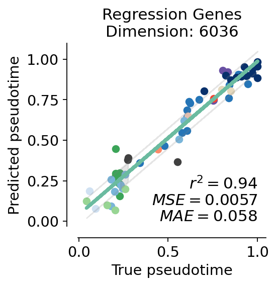

```python
cfg_obj.plot_color_fitting(type='filter',cluster_key='celltype')
```

cfg_obj.plot_color_fitting(type='filter',cluster_key='celltype')

```
(<Figure size 240x240 with 1 Axes>,
 <AxesSubplot: title={'center': 'Regression Genes\nDimension: 333'}, xlabel='True pseudotime', ylabel='Predicted pseudotime'>)
```

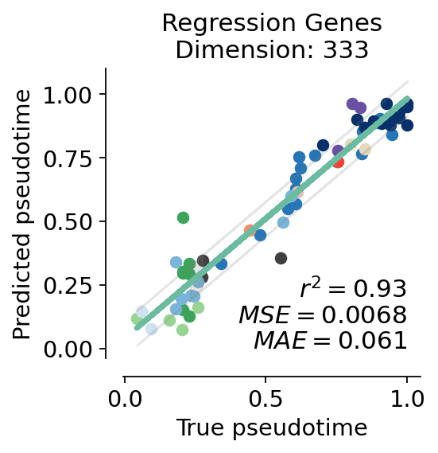

## Kendalltau test

We can further narrow down the set of genes that satisfy the maximum regression coefficient. We used the kendalltau test to calculate the trend significance for each gene.

```python
kt_filter=cfg_obj.kendalltau_filter()
kt_filter.head()
```

kt_filter=cfg_obj.kendalltau_filter() kt_filter.head()

|  | kendalltau_sta | pvalue |
| --- | --- | --- |
| kidney morphogenesis (GO:0060993) | -0.506842 | 3.358608e-25 |
| chromatin silencing at telomere (GO:0006348) | -0.428416 | 3.625202e-19 |
| apical protein localization (GO:0045176) | -0.102495 | 3.229373e-02 |
| fatty acid derivative catabolic process (GO:1901569) | -0.213859 | 7.950218e-06 |
| positive regulation of the force of heart contraction (GO:0098735) | 0.566918 | 1.637204e-30 |

```python
var_name=kt_filter.loc[kt_filter['pvalue']<kt_filter['pvalue'].mean()].index.tolist()
gt_obj=ov.single.gene_trends(adata_aucs,'pt_via',var_name)
gt_obj.calculate(n_convolve=10)
```

```python
print(f"Dimension: {len(var_name)}")
```

print(f"Dimension: {len(var_name)}")

```
Dimension: 269
```

```python
fig,ax=gt_obj.plot_trend(color=ov.utils.blue_color[3])
ax.set_title(f'Dentategyrus meta\nCellfategenie',fontsize=13)
```

fig,ax=gt_obj.plot_trend(color=ov.utils.blue_color[3]) ax.set_title(f'Dentategyrus meta\nCellfategenie',fontsize=13)

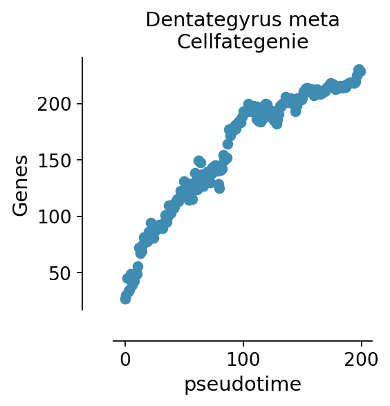

```python
g=ov.utils.plot_heatmap(adata_aucs,var_names=var_name,
                  sortby='pt_via',col_color='celltype',
                 n_convolve=10,figsize=(1,6),show=False)

g.fig.set_size_inches(2, 6)
g.fig.suptitle('CellFateGenie',x=0.25,y=0.83,
               horizontalalignment='left',fontsize=12,fontweight='bold')
g.ax_heatmap.set_yticklabels(g.ax_heatmap.get_yticklabels(),fontsize=12)
plt.show()
```

g=ov.utils.plot_heatmap(adata_aucs,var_names=var_name, sortby='pt_via',col_color='celltype', n_convolve=10,figsize=(1,6),show=False) g.fig.set_size_inches(2, 6) g.fig.suptitle('CellFateGenie',x=0.25,y=0.83, horizontalalignment='left',fontsize=12,fontweight='bold') g.ax_heatmap.set_yticklabels(g.ax_heatmap.get_yticklabels(),fontsize=12) plt.show()

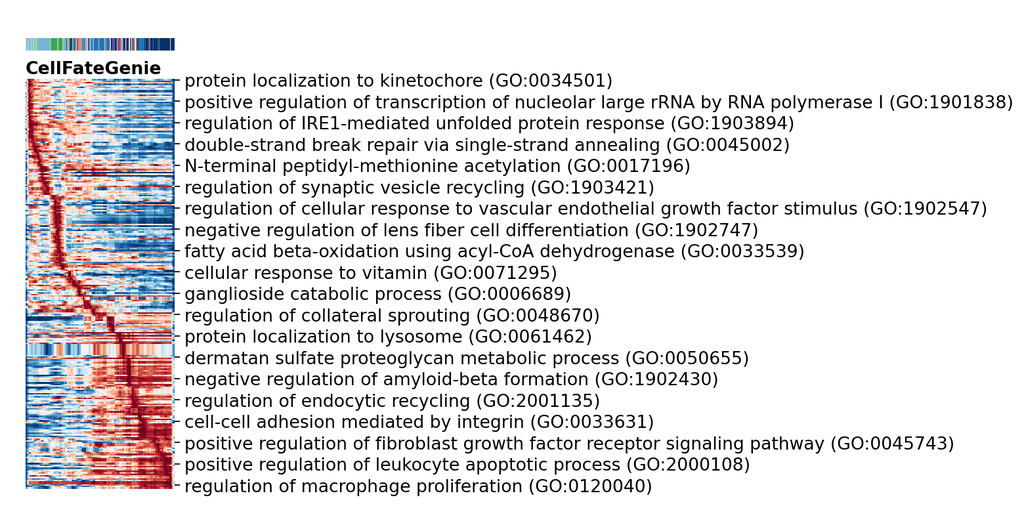

```python
gw_obj1=ov.utils.geneset_wordcloud(adata=adata_aucs[:,var_name],
                                  cluster_key='celltype',pseudotime='pt_via',figsize=(3,6))
gw_obj1.get()
```

gw_obj1=ov.utils.geneset_wordcloud(adata=adata_aucs[:,var_name], cluster_key='celltype',pseudotime='pt_via',figsize=(3,6)) gw_obj1.get()

```
Granule mature 300 26
Granule immature 300 4
Neuroblast 300 22
Cajal Retzius 300 37
GABA 300 37
Microglia 300 115
Mossy 300 44
nIPC 300 91
Astrocytes 300 53
OPC 300 17
Radial Glia-like 300 13
OL 300 69
Cck-Tox 300 64
```

```
{'Granule mature': <wordcloud.wordcloud.WordCloud at 0x7fdbe79be880>,
 'Granule immature': <wordcloud.wordcloud.WordCloud at 0x7fdb7f2797f0>,
 'Neuroblast': <wordcloud.wordcloud.WordCloud at 0x7fdb7efc4a30>,
 'Cajal Retzius': <wordcloud.wordcloud.WordCloud at 0x7fdb7efc4d00>,
 'GABA': <wordcloud.wordcloud.WordCloud at 0x7fdb7efc4b50>,
 'Microglia': <wordcloud.wordcloud.WordCloud at 0x7fdb7efc4ee0>,
 'Mossy': <wordcloud.wordcloud.WordCloud at 0x7fdb7efc4880>,
 'nIPC': <wordcloud.wordcloud.WordCloud at 0x7fdb7efc4c40>,
 'Astrocytes': <wordcloud.wordcloud.WordCloud at 0x7fdb7efc4c70>,
 'OPC': <wordcloud.wordcloud.WordCloud at 0x7fdb7f06b040>,
 'Radial Glia-like': <wordcloud.wordcloud.WordCloud at 0x7fdb7efc4e20>,
 'OL': <wordcloud.wordcloud.WordCloud at 0x7fdb7efc4be0>,
 'Cck-Tox': <wordcloud.wordcloud.WordCloud at 0x7fdb7efd7430>}
```

```python
g=gw_obj1.plot_heatmap(figwidth=6,cmap='RdBu_r')
plt.suptitle('CellFateGenie',x=0.18,y=0.95,
               horizontalalignment='left',fontsize=12,fontweight='bold')
```

g=gw_obj1.plot_heatmap(figwidth=6,cmap='RdBu_r') plt.suptitle('CellFateGenie',x=0.18,y=0.95, horizontalalignment='left',fontsize=12,fontweight='bold')

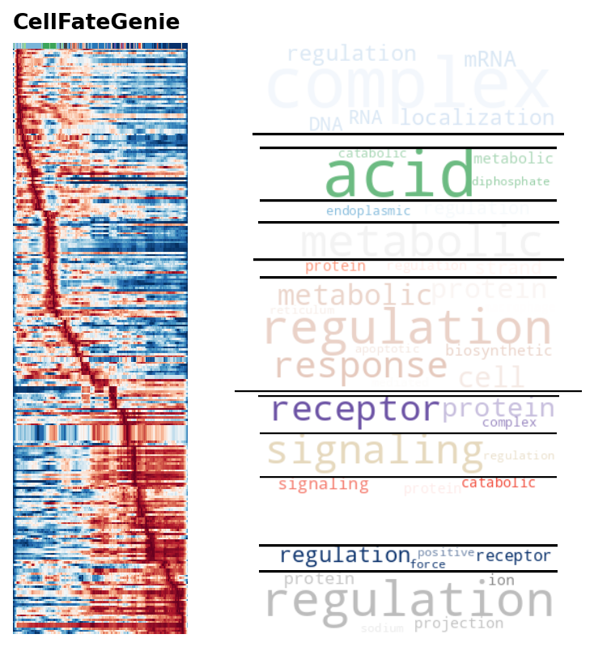